# missing_data_workshop

## Introduction to Missing Data Diagnostics and Treatment

### Speaker: Ricardo J. Serrano

### Objectives

- What is missing data?
- Missing data mechanisms (MCAR, MAR, MNAR)
- How to treat missing data the right way

### What is missing data?

[figure not shown]

### Missing Data Mechanisms

- Missing Completely at Random (MCAR)
- Missing at Random (MAR)
- Missing Not at Random (MNAR)

Source: Rubin (1976)

### Missing Completely at Random (MCAR)

- Locations of missing values in the dataset are purely random, they do not depend on any other data.
- Example: A weather sensor is measuring temperature and sending the data to a database. There are some missing entries in the database for when the sensor broke down.

### Missing at Random (MAR)

- Locations of missing values in the dataset depend on some other, observed data.
- There are some missing temperature values in the database for when the sensor was switched off for maintenance. As the maintenance team never work on the weekends, the locations of missing values depend on the day of the week.

### Missing Not at Random (MNAR)

- Locations of missing values in the dataset depend on the missing values themselves.
- When it's extremely cold, the weather sensor freezes and stops working. So, it does not record very low temperatures. Thus, the locations of missing values in the temperature variable depend on the values of this variable themselves.

### Why detecting the missing data mechanism is important?

- Imputation methods make assumptions on the type of missing data mechanism.
- Justifies the strategy to deal with missing data.

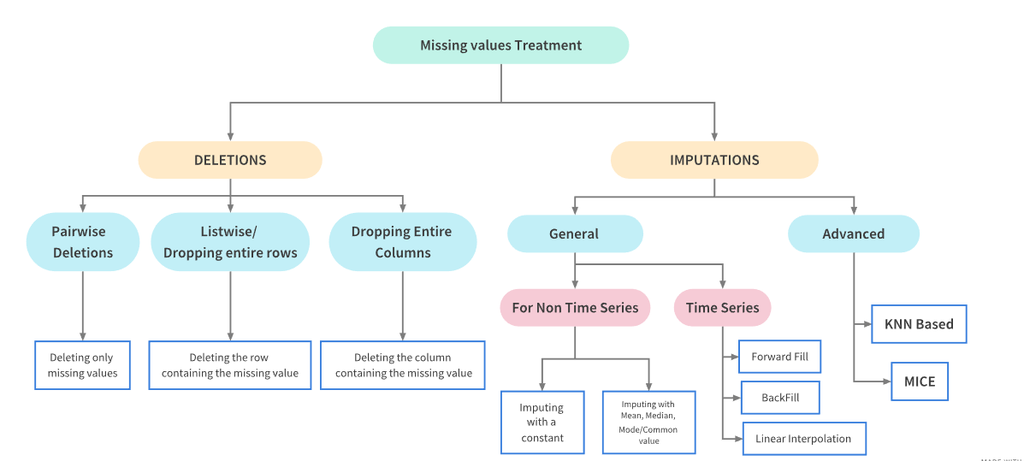

### How can the missing data mechanisms be detected?

- Data visualization
- Statistical tests

```python
# import libraries
import pandas as pd
import numpy as np
import missingno as msno
import matplotlib.pyplot as plt
import seaborn as sns

# supress warnings
import warnings
warnings.filterwarnings('ignore')

plt.rcParams["figure.figsize"] = (10,10)
```

```python
# read the Titanic dataset
df = pd.read_csv("train.csv")
```

```python
df.shape
```

```
(891, 12)
```

```python
df.head()
```

|  | PassengerId | Survived | Pclass | Name | Sex | Age | SibSp | Parch | Ticket | Fare | Cabin | Embarked |
| --- | --- | --- | --- | --- | --- | --- | --- | --- | --- | --- | --- | --- |
| 0 | 1 | 0 | 3 | Braund, Mr. Owen Harris | male | 22.0 | 1 | 0 | A/5 21171 | 7.2500 | NaN | S |
| 1 | 2 | 1 | 1 | Cumings, Mrs. John Bradley (Florence Briggs Th... | female | 38.0 | 1 | 0 | PC 17599 | 71.2833 | C85 | C |
| 2 | 3 | 1 | 3 | Heikkinen, Miss. Laina | female | 26.0 | 0 | 0 | STON/O2. 3101282 | 7.9250 | NaN | S |
| 3 | 4 | 1 | 1 | Futrelle, Mrs. Jacques Heath (Lily May Peel) | female | 35.0 | 1 | 0 | 113803 | 53.1000 | C123 | S |
| 4 | 5 | 0 | 3 | Allen, Mr. William Henry | male | 35.0 | 0 | 0 | 373450 | 8.0500 | NaN | S |

```python
df.tail()
```

|  | PassengerId | Survived | Pclass | Name | Sex | Age | SibSp | Parch | Ticket | Fare | Cabin | Embarked |
| --- | --- | --- | --- | --- | --- | --- | --- | --- | --- | --- | --- | --- |
| 886 | 887 | 0 | 2 | Montvila, Rev. Juozas | male | 27.0 | 0 | 0 | 211536 | 13.00 | NaN | S |
| 887 | 888 | 1 | 1 | Graham, Miss. Margaret Edith | female | 19.0 | 0 | 0 | 112053 | 30.00 | B42 | S |
| 888 | 889 | 0 | 3 | Johnston, Miss. Catherine Helen "Carrie" | female | NaN | 1 | 2 | W./C. 6607 | 23.45 | NaN | S |
| 889 | 890 | 1 | 1 | Behr, Mr. Karl Howell | male | 26.0 | 0 | 0 | 111369 | 30.00 | C148 | C |
| 890 | 891 | 0 | 3 | Dooley, Mr. Patrick | male | 32.0 | 0 | 0 | 370376 | 7.75 | NaN | Q |

```python
df.info()
```

```
<class 'pandas.core.frame.DataFrame'>
RangeIndex: 891 entries, 0 to 890
Data columns (total 12 columns):
 #   Column       Non-Null Count  Dtype
---  ------       --------------  -----
 0   PassengerId  891 non-null    int64
 1   Survived     891 non-null    int64
 2   Pclass       891 non-null    int64
 3   Name         891 non-null    object
 4   Sex          891 non-null    object
 5   Age          714 non-null    float64
 6   SibSp        891 non-null    int64
 7   Parch        891 non-null    int64
 8   Ticket       891 non-null    object
 9   Fare         891 non-null    float64
 10  Cabin        204 non-null    object
 11  Embarked     889 non-null    object
dtypes: float64(2), int64(5), object(5)
memory usage: 83.7+ KB
```

```python
df.describe()
```

|  | PassengerId | Survived | Pclass | Age | SibSp | Parch | Fare |
| --- | --- | --- | --- | --- | --- | --- | --- |
| count | 891.000000 | 891.000000 | 891.000000 | 714.000000 | 891.000000 | 891.000000 | 891.000000 |
| mean | 446.000000 | 0.383838 | 2.308642 | 29.699118 | 0.523008 | 0.381594 | 32.204208 |
| std | 257.353842 | 0.486592 | 0.836071 | 14.526497 | 1.102743 | 0.806057 | 49.693429 |
| min | 1.000000 | 0.000000 | 1.000000 | 0.420000 | 0.000000 | 0.000000 | 0.000000 |
| 25% | 223.500000 | 0.000000 | 2.000000 | 20.125000 | 0.000000 | 0.000000 | 7.910400 |
| 50% | 446.000000 | 0.000000 | 3.000000 | 28.000000 | 0.000000 | 0.000000 | 14.454200 |
| 75% | 668.500000 | 1.000000 | 3.000000 | 38.000000 | 1.000000 | 0.000000 | 31.000000 |
| max | 891.000000 | 1.000000 | 3.000000 | 80.000000 | 8.000000 | 6.000000 | 512.329200 |

```python
# credit: https://www.kaggle.com/willkoehrsen/start-here-a-gentle-introduction.
# One of the best notebooks on getting started with a ML problem.

def missing_values_table(df):
        # Total missing values
        mis_val = df.isnull().sum()

        # Percentage of missing values
        mis_val_percent = 100 * df.isnull().sum() / len(df)

        # Make a table with the results
        mis_val_table = pd.concat([mis_val, mis_val_percent], axis=1)

        # Rename the columns
        mis_val_table_ren_columns = mis_val_table.rename(
        columns = {0 : 'Missing Values', 1 : '% of Total Values'})

        # Sort the table by percentage of missing descending
        mis_val_table_ren_columns = mis_val_table_ren_columns[
            mis_val_table_ren_columns.iloc[:,1] != 0].sort_values(
        '% of Total Values', ascending=False).round(1)

        # Print some summary information
        print ("Your selected dataframe has " + str(df.shape[1]) + " columns.\n"
            "There are " + str(mis_val_table_ren_columns.shape[0]) +
              " columns that have missing values.")

        # Return the dataframe with missing information
        return mis_val_table_ren_columns
```

```python
# verify missing values
missing_values_table(df)
```

```
Your selected dataframe has 12 columns.
There are 3 columns that have missing values.
```

|  | Missing Values | % of Total Values |
| --- | --- | --- |
| Cabin | 687 | 77.1 |
| Age | 177 | 19.9 |
| Embarked | 2 | 0.2 |

Three features have missing values present: `Cabin`, `Age` and `Embarked`.

### Exploring missing data with `missingno` library

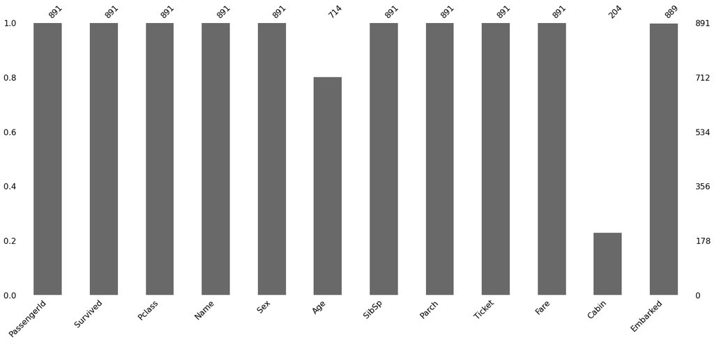

```python
msno.bar(df)
```

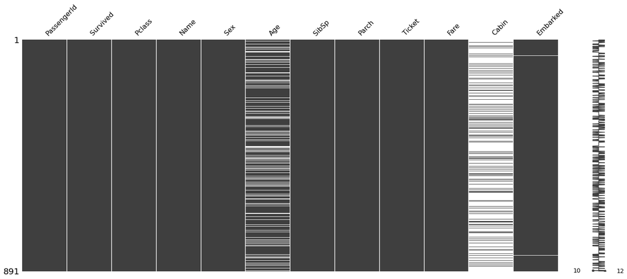

```python
msno.matrix(df)
```

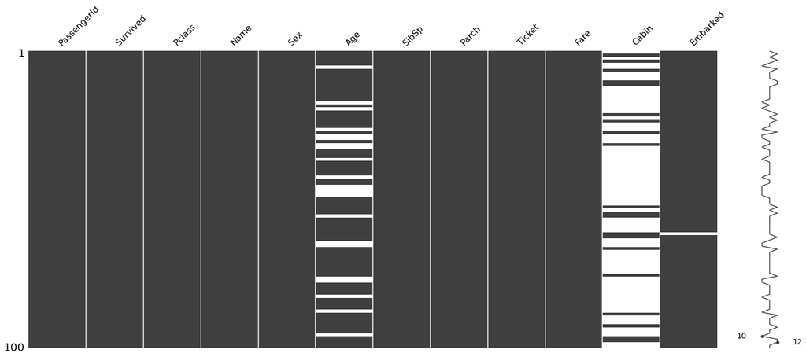

```python
# visualize missing values for first 100 rows
msno.matrix(df.loc[:99, ])
```

### What do you notice regarding missing values distribution?

[figure not shown]

- `Embarked` feature seems to quality for MCAR, since there is no apparent relationship with other features.
- `Cabin` and `Age` could be classified as MAR (there is no direct cause for missingness based on the observed values).

### What about MCAR?

- In R, the `BaylorEdPsych` library provides a test for MCAR (LittleMCAR). However, this library is not currently maintained (use at your own risk!).
- IBM/SPSS commercial package provides a tes for MCAR.
- To my knowledge, there is no implemtation in Python to test MCAR assumption.

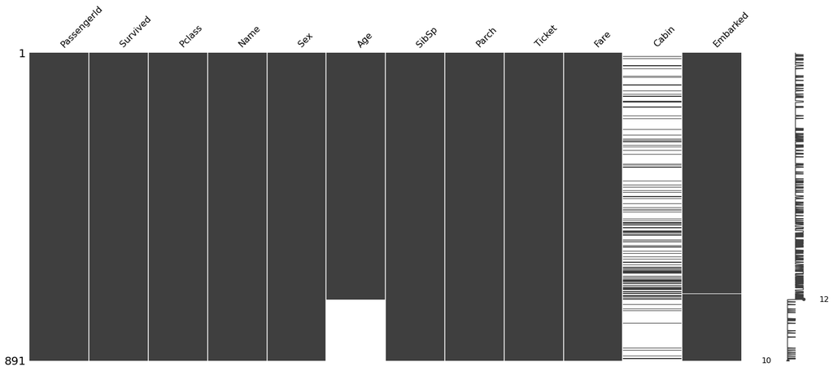

```python
# `age` (sorted) and `cabin` plot
sorted = df.sort_values('Age')
msno.matrix(sorted)
```

### Heatmap

- In `msno`, the heatmap function shows the correlation of missingness between every 2 columns.
- A value near `-1` means if one variable appears then the other variable is very likely to be missing.
- A value near `0` means there is no dependence between the occurrence of missing values of two variables. A value near 0 is an indication of MAR.
- A value near `1` means if one variable appears then the other variable is very likely to be present.

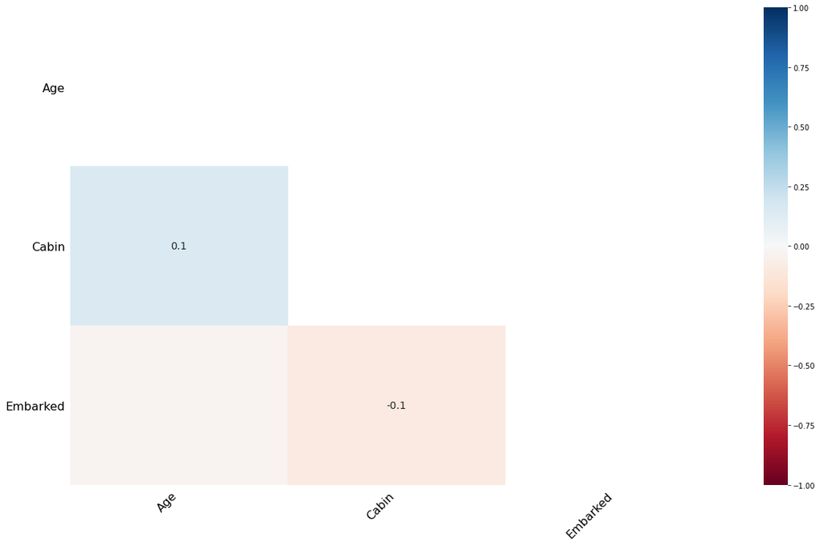

```python
# heatmap
msno.heatmap(df)
```

There is no strong correlation between `cabin` and `age`, pointing to `MAR` mechanism.

### Imputing missing values

- `Embarked` - only two missing values. Assuming MCAR. Proposed impute methodology: mode imputation.
- `Cabin` - 77% missing values. In practical terms, this feature will be a candidate for column deletion. An alternate strategy will be to use `mice` to impute the cabin first letter.
- `Age` - ~20% missing values. From extensive EDA done by data scientists, this feature is a valuable predictor for the target (`Survived`). The strategy is to use model-based approach (i.e. mice) to impute this feature.

### Imputing `Embarked`

```python
df_imp = df.copy()
```

```python
# `Embarked` value count
df_imp.Embarked.value_counts()
```

```
S    644
C    168
Q     77
Name: Embarked, dtype: int64
```

```python
# use fillna to impute `Embarked` missing values with mode ('S')
df_imp['Embarked'].fillna(df_imp.Embarked.mode()[0], inplace=True)
```

```python
df_imp['Embarked'].isnull().sum()
```

```
0
```

### Use `mice` to impute `Cabin` and `Age`

[figure not shown]

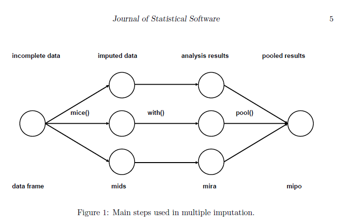

This is a very powerful algorithm that basically works by selecting one feature with missing values as the target variable and utilises a regression model to impute the missing values based on all the other variables in the dataset. Source: https://towardsdatascience.com/3-underrated-strategies-to-deal-with-missing-values-a539fb6c0690

```python
# import sklearn functions
from sklearn import preprocessing
from sklearn.experimental import enable_iterative_imputer
from sklearn.impute import IterativeImputer
```

```python
# extract first `Cabin` letter, create Cabin_letter feature
df_imp['Cabin_letter'] = df_imp['Cabin'].str[0]
```

```python
# drop unnecessary features for `mice`
df_imp = df_imp.drop(['PassengerId','Name', 'Ticket', 'Cabin'],axis=1)
```

```python
df_imp.head()
```

|  | Survived | Pclass | Sex | Age | SibSp | Parch | Fare | Embarked | Cabin_letter |
| --- | --- | --- | --- | --- | --- | --- | --- | --- | --- |
| 0 | 0 | 3 | male | 22.0 | 1 | 0 | 7.2500 | S | NaN |
| 1 | 1 | 1 | female | 38.0 | 1 | 0 | 71.2833 | C | C |
| 2 | 1 | 3 | female | 26.0 | 0 | 0 | 7.9250 | S | NaN |
| 3 | 1 | 1 | female | 35.0 | 1 | 0 | 53.1000 | S | C |
| 4 | 0 | 3 | male | 35.0 | 0 | 0 | 8.0500 | S | NaN |

```python
df_imp.Cabin_letter.value_counts(dropna=False)
```

```
NaN    687
C       59
B       47
D       33
E       32
A       15
F       13
G        4
T        1
Name: Cabin_letter, dtype: int64
```

```python
df_encoded = df_imp.copy()
```

```python
# label_encoder object knows how to understand word labels
le = preprocessing.LabelEncoder()
```

```python
# select `object` data types from df_imp
objList = df_encoded.select_dtypes(include = "object").columns
```

```python
print(objList)
```

```
Index(['Sex', 'Embarked', 'Cabin_letter'], dtype='object')
```

```python
# Encode labels in 'Sex`, `Embarked` and `Cabin_Letter'
for i in objList:
    df_encoded[i] = le.fit_transform(df_encoded[i].astype(str))
```

```python
df_encoded.head()
```

|  | Survived | Pclass | Sex | Age | SibSp | Parch | Fare | Embarked | Cabin_letter |
| --- | --- | --- | --- | --- | --- | --- | --- | --- | --- |
| 0 | 0 | 3 | 1 | 22.0 | 1 | 0 | 7.2500 | 2 | 8 |
| 1 | 1 | 1 | 0 | 38.0 | 1 | 0 | 71.2833 | 0 | 2 |
| 2 | 1 | 3 | 0 | 26.0 | 0 | 0 | 7.9250 | 2 | 8 |
| 3 | 1 | 1 | 0 | 35.0 | 1 | 0 | 53.1000 | 2 | 2 |
| 4 | 0 | 3 | 1 | 35.0 | 0 | 0 | 8.0500 | 2 | 8 |

```python
# replace 8 in `Cabin_Letter` with np.nan
df_encoded['Cabin_letter'].replace(8, np.nan, inplace=True)
```

```python
df_encoded.head()
```

|  | Survived | Pclass | Sex | Age | SibSp | Parch | Fare | Embarked | Cabin_letter |
| --- | --- | --- | --- | --- | --- | --- | --- | --- | --- |
| 0 | 0 | 3 | 1 | 22.0 | 1 | 0 | 7.2500 | 2 | NaN |
| 1 | 1 | 1 | 0 | 38.0 | 1 | 0 | 71.2833 | 0 | 2.0 |
| 2 | 1 | 3 | 0 | 26.0 | 0 | 0 | 7.9250 | 2 | NaN |
| 3 | 1 | 1 | 0 | 35.0 | 1 | 0 | 53.1000 | 2 | 2.0 |
| 4 | 0 | 3 | 1 | 35.0 | 0 | 0 | 8.0500 | 2 | NaN |

```python
# execute IterativeImputer (`mice`) to df_encoded
imputer = IterativeImputer(imputation_order='ascending', max_iter=20, random_state=42, n_nearest_features=None)

imputed_dataset = imputer.fit_transform(df_encoded)
```

```python
pd.DataFrame(imputed_dataset)
```

|  | 0 | 1 | 2 | 3 | 4 | 5 | 6 | 7 | 8 |
| --- | --- | --- | --- | --- | --- | --- | --- | --- | --- |
| 0 | 0.0 | 3.0 | 1.0 | 22.000000 | 1.0 | 0.0 | 7.2500 | 2.0 | 5.224777 |
| 1 | 1.0 | 1.0 | 0.0 | 38.000000 | 1.0 | 0.0 | 71.2833 | 0.0 | 2.000000 |
| 2 | 1.0 | 3.0 | 0.0 | 26.000000 | 0.0 | 0.0 | 7.9250 | 2.0 | 5.194769 |
| 3 | 1.0 | 1.0 | 0.0 | 35.000000 | 1.0 | 0.0 | 53.1000 | 2.0 | 2.000000 |
| 4 | 0.0 | 3.0 | 1.0 | 35.000000 | 0.0 | 0.0 | 8.0500 | 2.0 | 4.957144 |
| ... | ... | ... | ... | ... | ... | ... | ... | ... | ... |
| 886 | 0.0 | 2.0 | 1.0 | 27.000000 | 0.0 | 0.0 | 13.0000 | 2.0 | 3.614325 |
| 887 | 1.0 | 1.0 | 0.0 | 19.000000 | 0.0 | 0.0 | 30.0000 | 2.0 | 1.000000 |
| 888 | 0.0 | 3.0 | 0.0 | 23.266626 | 1.0 | 2.0 | 23.4500 | 2.0 | 5.357172 |
| 889 | 1.0 | 1.0 | 1.0 | 26.000000 | 0.0 | 0.0 | 30.0000 | 0.0 | 2.000000 |
| 890 | 0.0 | 3.0 | 1.0 | 32.000000 | 0.0 | 0.0 | 7.7500 | 1.0 | 4.757363 |

891 rows × 9 columns

```python
# assign numpy array column 3 (age_imp) and column 8 (Cabin_letter_imp) to df_encoded
df_encoded['age_imp'] = imputed_dataset[:, 3]
df_encoded['Cabin_letter_imp'] = imputed_dataset[:, 8]
```

```python
df_encoded.head(10)
```

|  | Survived | Pclass | Sex | Age | SibSp | Parch | Fare | Embarked | Cabin_letter | age_imp | Cabin_letter_imp |
| --- | --- | --- | --- | --- | --- | --- | --- | --- | --- | --- | --- |
| 0 | 0 | 3 | 1 | 22.0 | 1 | 0 | 7.2500 | 2 | NaN | 22.000000 | 5.224777 |
| 1 | 1 | 1 | 0 | 38.0 | 1 | 0 | 71.2833 | 0 | 2.0 | 38.000000 | 2.000000 |
| 2 | 1 | 3 | 0 | 26.0 | 0 | 0 | 7.9250 | 2 | NaN | 26.000000 | 5.194769 |
| 3 | 1 | 1 | 0 | 35.0 | 1 | 0 | 53.1000 | 2 | 2.0 | 35.000000 | 2.000000 |
| 4 | 0 | 3 | 1 | 35.0 | 0 | 0 | 8.0500 | 2 | NaN | 35.000000 | 4.957144 |
| 5 | 0 | 3 | 1 | NaN | 0 | 0 | 8.4583 | 1 | NaN | 28.567202 | 4.763148 |
| 6 | 0 | 1 | 1 | 54.0 | 0 | 0 | 51.8625 | 2 | 4.0 | 54.000000 | 4.000000 |
| 7 | 0 | 3 | 1 | 2.0 | 3 | 1 | 21.0750 | 2 | NaN | 2.000000 | 5.717143 |
| 8 | 1 | 3 | 0 | 27.0 | 0 | 2 | 11.1333 | 2 | NaN | 27.000000 | 5.223825 |
| 9 | 1 | 2 | 0 | 14.0 | 1 | 0 | 30.0708 | 0 | NaN | 14.000000 | 3.624895 |

```python
df_encoded['Cabin_letter_imp'] = df_encoded['Cabin_letter_imp'].apply(lambda x: round(x, 0))
```

```python
df_encoded.head(10)
```

|  | Survived | Pclass | Sex | Age | SibSp | Parch | Fare | Embarked | Cabin_letter | age_imp | Cabin_letter_imp |
| --- | --- | --- | --- | --- | --- | --- | --- | --- | --- | --- | --- |
| 0 | 0 | 3 | 1 | 22.0 | 1 | 0 | 7.2500 | 2 | NaN | 22.000000 | 5.0 |
| 1 | 1 | 1 | 0 | 38.0 | 1 | 0 | 71.2833 | 0 | 2.0 | 38.000000 | 2.0 |
| 2 | 1 | 3 | 0 | 26.0 | 0 | 0 | 7.9250 | 2 | NaN | 26.000000 | 5.0 |
| 3 | 1 | 1 | 0 | 35.0 | 1 | 0 | 53.1000 | 2 | 2.0 | 35.000000 | 2.0 |
| 4 | 0 | 3 | 1 | 35.0 | 0 | 0 | 8.0500 | 2 | NaN | 35.000000 | 5.0 |
| 5 | 0 | 3 | 1 | NaN | 0 | 0 | 8.4583 | 1 | NaN | 28.567202 | 5.0 |
| 6 | 0 | 1 | 1 | 54.0 | 0 | 0 | 51.8625 | 2 | 4.0 | 54.000000 | 4.0 |
| 7 | 0 | 3 | 1 | 2.0 | 3 | 1 | 21.0750 | 2 | NaN | 2.000000 | 6.0 |
| 8 | 1 | 3 | 0 | 27.0 | 0 | 2 | 11.1333 | 2 | NaN | 27.000000 | 5.0 |
| 9 | 1 | 2 | 0 | 14.0 | 1 | 0 | 30.0708 | 0 | NaN | 14.000000 | 4.0 |

### Imputation quality

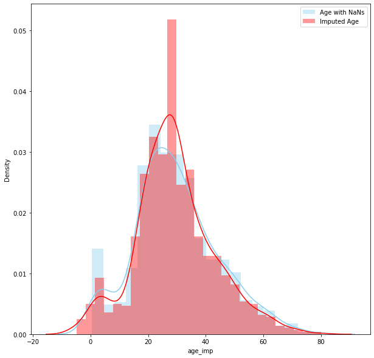

```python
# distplot for `Age` and `age_imp`
sns.distplot( df_encoded['Age'] , color="skyblue", label='Age with NaNs')
sns.distplot( df_encoded['age_imp'] , color="red", label='Imputed Age')
plt.legend()
```